# Summary Tables with gtsummary

M08 Reflection · Revealjs Presentation

Kevin Bachez

IBM 6500, Cal Poly Pomona

2026-11-10

# Introduction

## About This Presentation

This deck reflects on **Module 8**, where I learned to turn statistical output into publication-ready tables with {gtsummary} (Sjoberg et al. 2021).

- **Prompt 1:** capabilities of {gtsummary} (Step 1 lecture)
- **Prompt 2:** Daniel Sjoberg’s talk, compared with {gt} and {gtExtras}
- **Prompt 3:** cross-tabulation with my MSDM CEP data
- **Prompt 4:** multiple regression with my MSDM CEP data

**How to read this deck**

Each section opens with the **original prompt** so readers who have not seen the assignment can follow along. My response follows right after.

## Packages Used

```r
library(tidyverse)   # data wrangling
library(gt)          # display tables
library(gtsummary)   # statistical summary tables
```

All three are on CRAN. {gtsummary} renders its tables through {gt} by default.<sup>1</sup>

[^1]: {gtsummary} can also print through other engines such as {flextable}, {huxtable}, and {kableExtra}.

# Prompt 1: Capabilities of {gtsummary}

## Prompt 1

**Prompt**

*In Step 1, you have seen how to create a summary table and modify it for various statistical analyses. Summarize the package’s capabilities as explained by the speaker. How may the {gtsummary} benefit you for your school work or career?*

## 1.1 What {gtsummary} Can Do

**Descriptive & group comparisons**

- `tbl_summary()` detects variable types and reports median (Q1, Q3) or n (%) automatically.
- `add_p()` adds tests: Wilcoxon rank-sum for continuous, chi-square for categorical.
- `add_difference()` reports mean differences with 95% CIs (Welch t-test), and ANCOVA with `adj.vars`.
- `tbl_cross()` builds clean cross-tabs with totals.
- `add_q()` adjusts for multiple comparisons.

**Models & presentation**

- `tbl_regression()` formats `lm()` / `glm()` output; `exponentiate = TRUE` gives odds ratios.
- `add_global_p()`, `add_vif()`, `add_glance_table()` add model diagnostics.
- `tbl_uvregression()` runs many one-predictor models at once.
- `tbl_merge()` / `tbl_stack()` combine tables side by side or vertically.
- Journal themes (JAMA, QJE) restyle every table at once.

A key caution from the lecture: showing `{mean} ({sd})` does **not** change the test used by `add_p()`. Use `add_difference()` for a t-test.

## 1.2 Quick Demonstration

- Code
- Table

```r
trial |>
  select(trt, age, grade, response) |>
  tbl_summary(by = trt, missing = "no") |>
  add_p() |>
  add_overall() |>
  bold_labels()
```

| **Characteristic** | **Overall** N = 200<sup>1</sup> | **Drug A** N = 98<sup>1</sup> | **Drug B** N = 102<sup>1</sup> | **p-value**<sup>2</sup> |
| --- | --- | --- | --- | --- |
| Age | 47 (38, 57) | 46 (37, 60) | 48 (39, 56) | 0.7 |
| Grade |  |  |  | 0.9 |
| I | 68 (34%) | 35 (36%) | 33 (32%) |  |
| II | 68 (34%) | 32 (33%) | 36 (35%) |  |
| III | 64 (32%) | 31 (32%) | 33 (32%) |  |
| Tumor Response | 61 (32%) | 28 (29%) | 33 (34%) | 0.5 |

<sup>1</sup> Median (Q1, Q3); n (%)  
<sup>2</sup> Wilcoxon rank sum test; Pearson’s Chi-squared test

## 1.3 How It Benefits Me

- **School work:** As the AO2 analytics lead on our Wellness Ranch CEP, I have to turn GA4 and BigQuery data into results my professor and our client can read. {gtsummary} let me build Tables 1 and 2 in this deck directly from the session data, and it made me choose tests on purpose: `add_p()` and `add_difference()` do not run the same test.
- **Reproducibility:** Our BigQuery export grows every day. When I rerun the query with more days, every table and every number written with `inline_text()` updates on its own, so I never retype figures into slides or mix up reporting periods.
- **Career:** In digital marketing analytics, I will regularly present channel and campaign results to people who are not statisticians. Clear labels, confidence intervals, and journal themes help me deliver tables that look professional and are easy to defend.

# Prompt 2: Sjoberg’s Talk

## Prompt 2

**Prompt**

*In Step 2, you watched the extended presentation of the {gtsummary} package by Dr. Daniel Sjoberg, the very creator of the package.*

*2.1. How does it differ from gt and gtExtras?*

*2.2. Give three things you learned newly that were not explained in the lecture in Step 1.*

## 2.1 {gtsummary} vs. {gt} vs. {gtExtras}

**How the three packages fit together**

| Package | Main job | Computes statistics? | Typical input | Best for |
| --- | --- | --- | --- | --- |
| {gt} | A grammar for building display tables from any data frame | No | Any data frame | Full control of layout |
| {gtExtras} | Add-ons for {gt}: ready-made themes, sparklines, bar charts and color scales inside cells | No | A gt table | Eye-catching dashboards and reports |
| {gtsummary} | Computes statistics, tests, and model results, then formats them as a table | Yes | Raw data or a fitted model | Table 1s, hypothesis tests, regression tables |

In short: {gt} *draws* tables, {gtExtras} *decorates* them, and {gtsummary} *does the statistics* and then hands the result to {gt} via `as_gt()` (Iannone et al. 2026; Mock 2026).

## 2.2 Three New Things I Learned

Sjoberg’s talk went beyond the lecture by showing how {gtsummary} fits into a full reporting workflow, not just how to build one table.

**1. Inline reporting with `inline_text()`** — any number in a table can be pulled directly into a sentence, so the written interpretation updates along with the data. I used this for every coefficient in Prompt 4.

**2. Multiple output engines** — the same table can go to {gt} for HTML, `as_flex_table()` for Word, or `as_kable_extra()` for PDF, and can be saved directly as an HTML, Word, RTF, or image file. That matters because our Wellness Ranch client handoff will likely be a Word or PDF report, not a website.

**3. The design behind it** — {gtsummary} builds on {broom} to tidy model output, {gt} to display tables, and {labelled} for variable labels. That explains why it recognizes a logistic model and labels the column “OR” without being told.

# Prompt 3: Cross-Tabulation

## Prompt 3

**Prompt**

*Apply what you learned to your MSDM CEP data. Choose two appropriate variables for cross-tabulation and show if the two variables are associated or not. Use appropriate statistics to test if the two variables are associated. Code, produce the table, and interpret the result.*

## 3.1 The Data: Wellness Ranch Website Sessions

```r
raw <- read_csv("data/wr_sessions.csv",
                col_types = cols(user_pseudo_id = col_character()))

# Team test device (Tag Assistant / Wix editor visits on Nov 5-6)
test_user <- "2052470512.1791501040"

wr <- raw |>
  filter(user_pseudo_id != test_user) |>
  mutate(
    channel = case_when(
      is.na(source) & is.na(medium) ~ "Direct",
      medium == "organic"           ~ "Organic search",
      medium == "social"            ~ "Organic social",
      TRUE                          ~ "Referral"),
    channel = factor(channel, levels = c("Direct", "Organic search",
                                         "Organic social", "Referral")),
    device  = factor(device, levels = c("mobile", "desktop"),
                     labels = c("Mobile", "Desktop")),
    engaged = factor(engaged, levels = c(1, 0),
                     labels = c("Engaged", "Not engaged")),
    visitor = factor(is_new_user, levels = c(0, 1),
                     labels = c("Returning", "New")),
    log_eng = log1p(engagement_sec))
```

- **Source:** GA4 → BigQuery export (`analytics_558215559`), one row per session
- **Period:** Nov 4–9, 2026 (the full extent of the export)
- **Sessions:** 243 exported; 5 from our own test device removed → **238 sessions** from 188 visitors
- Channels were grouped from GA4’s `source` / `medium` fields

## 3.2 Variables & Hypotheses

**Acquisition channel** (row, categorical)

How the session arrived: Direct, Organic search (Google, Bing, Yahoo, DuckDuckGo), Organic social (Instagram, Facebook), or Referral.

**Engaged session** (column, dichotomous)

GA4 counts a session as engaged if it lasts 10+ seconds, has 2+ page views, or includes a key event.

**H₀:** Engagement is independent of acquisition channel.

**H₁:** The share of engaged sessions differs by channel.

This answers **RQ2** of our CEP analysis plan: *Does engagement differ by acquisition channel?*

## 3.3 Cross-Tabulation Table

```r
tbl_cross(
  data = wr,
  row = channel,
  col = engaged,
  percent = "row",
  label = list(channel ~ "Acquisition channel",
               engaged ~ "Session engagement"),
  missing = "no"
) |>
  add_p(test = "fisher.test") |>
  bold_labels() |>
  modify_caption(
    "**Table 1. Engaged sessions by acquisition channel, Nov 4–9, 2026**")
```

**Table 1. Engaged sessions by acquisition channel, Nov 4–9, 2026**

|  | **Session engagement** Engaged | **Session engagement** Not engaged | **Total** | **p-value**<sup>1</sup> |  |  |
| --- | --- | --- | --- | --- | --- | --- |
| Acquisition channel |  |  |  |  |  | <0.001 |
| Direct | 48 (44%) | 60 (56%) | 108 (100%) |  |  |  |
| Organic search | 75 (85%) | 13 (15%) | 88 (100%) |  |  |  |
| Organic social | 30 (83%) | 6 (17%) | 36 (100%) |  |  |  |
| Referral | 5 (83%) | 1 (17%) | 6 (100%) |  |  |  |
| Total | 158 (66%) | 80 (34%) | 238 (100%) |  |  |  |

<sup>1</sup> Fisher’s exact test

Row percentages show the engagement rate *within* each channel. Fisher’s exact test is used because the Referral row has expected counts below 5.

## 3.4 Interpretation

**Result**

Engagement **is associated** with acquisition channel: χ²(3) = 42.7, Fisher’s exact p<0.001, Cramér’s V = 0.42 (a medium-to-large effect).

- About **85%** of organic-search sessions and **83%** of organic-social sessions were engaged, versus only **44%** of direct sessions.
- Visitors who *chose* to click through from Google or Instagram arrive with intent; they stay, scroll, and view more pages.
- **Caution about “Direct”:** 23 of the 108 direct sessions recorded *no page view at all*, which points to tracking gaps rather than real visits. Among direct sessions with at least one page view, the engagement rate rises to 54%, but it is still lower than the search and social channels.
- **Device check (RQ5):** engagement did *not* differ between mobile and desktop (χ²(1) = 0.14, p=0.7).
- **For the client:** search and Instagram bring the most engaged visitors, which supports the SEO (AO1) and social outreach (AO4) objectives.

# Prompt 4: Multiple Regression

## Prompt 4

**Prompt**

*Using the MSDM CEP data, run multiple regression. The dependent variable can be continuous or dichotomous. Regress a dependent variable on a set of independent variables. Code, produce the table, and interpret the result.*

## 4.1 Choosing the Dependent Variable

- **DV:** engagement time per session (seconds), GA4’s `engagement_time_msec` summed per session.
- It is very right-skewed: median 14.5 s, mean 65.3 s, max 1195 s, and 31% of sessions have zero.
- So I model **log(1 + seconds)**, which handles zeros and pulls in extreme values.
- **Why not leads or donations?** Only 5 sessions had a lead and 0 had donation interest, too few to model.
- Raw seconds
- log(1 + seconds)

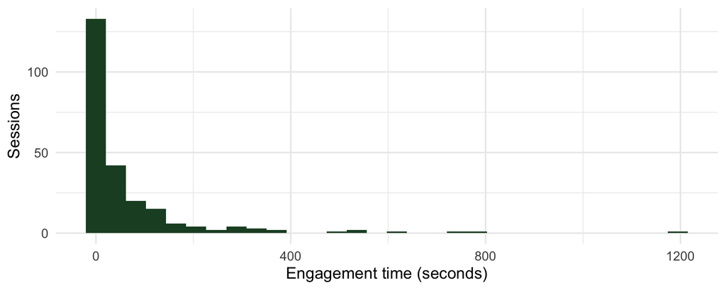

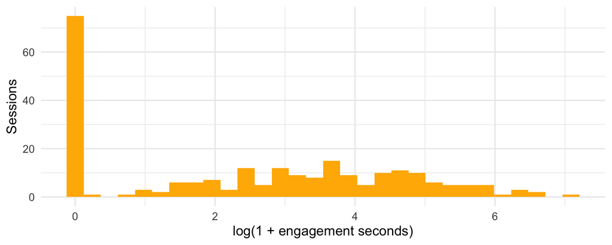

## 4.2 Regression Model and Table

```r
m_wr <- lm(log_eng ~ device + channel + visitor, data = wr)

reg_tbl <- m_wr |>
  tbl_regression(
    label = list(device ~ "Device",
                 channel ~ "Acquisition channel",
                 visitor ~ "Visitor type"),
    pvalue_fun = label_style_pvalue(digits = 2)) |>
  add_vif() |>
  add_glance_table(
    include = c(r.squared, adj.r.squared, nobs)) |>
  bold_p(t = 0.05) |>
  bold_labels() |>
  modify_caption(
    "**Table 2. OLS predicting log(1 + engagement seconds)**")

reg_tbl
```

**Table 2. OLS predicting log(1 + engagement seconds)**

| **Characteristic** | **Beta** | **95% CI** | **p-value** | **GVIF** | **Adjusted GVIF**<sup>1</sup> |
| --- | --- | --- | --- | --- | --- |
| Device |  |  |  | 1.1 | 1.1 |
| Mobile | — | — |  |  |  |
| Desktop | 0.27 | -0.26, 0.81 | 0.31 |  |  |
| Acquisition channel |  |  |  | 1.3 | 1.0 |
| Direct | — | — |  |  |  |
| Organic search | 1.5 | 0.94, 2.1 | <0.001 |  |  |
| Organic social | 1.4 | 0.64, 2.2 | <0.001 |  |  |
| Referral | 0.79 | -0.78, 2.4 | 0.32 |  |  |
| Visitor type |  |  |  | 1.2 | 1.1 |
| Returning | — | — |  |  |  |
| New | 0.92 | 0.36, 1.5 | 0.002 |  |  |
| R² | 0.211 |  |  |  |  |
| Adjusted R² | 0.194 |  |  |  |  |
| No. Obs. | 238 |  |  |  |  |

[^2]: 1/(2*df)

## 4.3 Interpretation

**Model fit**

Device, channel, and visitor type together explain about 19% of the variation in log engagement time (adjusted R²), F(5, 232) = 12.42, p<0.001. All adjusted GVIFs are near 1, so multicollinearity is not a concern.

- **Organic search:** β = 1.5 (95% CI 0.94, 2.1; p<0.001). Holding device and visitor type constant, search sessions run about **4.5×** as long as direct sessions (on the 1 + seconds scale).
- **Organic social:** β = 1.4 (95% CI 0.64, 2.2; p<0.001), about **4.1×** as long as direct.
- **New visitors:** β = 0.92 (95% CI 0.36, 1.5; p=0.002), about **2.5×** as long as returning visitors. Returning visitors may come back for a quick task, such as checking a date or finding a link.
- **Device** (desktop vs. mobile: β = 0.27 (95% CI -0.26, 0.81; p=0.3)) and **Referral** were not significant; Referral has only 6 sessions.

Because the DV is log-transformed, exp(β) gives a multiplicative effect. Every β and CI on this slide is inserted with `inline_text()`.

## 4.4 Limitations

- **Short window:** six days of data; results describe early November only.
- **Not fully independent:** some visitors had several sessions (238 sessions from 188 visitors).
- **Many zeros:** 31% of sessions have zero engagement time; a two-part or count model could handle this better.
- **“Direct” is partly a tracking category:** sessions without source information fall here, which may exaggerate the gap between Direct and other channels.
- **Correlation, not causation:** the model shows which kinds of visits last longer, not what *causes* engagement.

# Wrap-Up

## Key Takeaways

- {gtsummary} turns analysis results into publication-ready tables with very little code.
- Choose the test on purpose: `add_p()` and `add_difference()` do different things.
- `inline_text()` and Quarto keep tables **and** text reproducible.

Thank you!

## References

Iannone, Richard, Joe Cheng, Barret Schloerke, Shannon Haughton, Ellis Hughes, Alexandra Lauer, Romain François, JooYoung Seo, Ken Brevoort, and Olivier Roy. 2026. *Gt: Easily Create Presentation-Ready Display Tables*. https://gt.rstudio.com.

Mock, Thomas. 2026. *gtExtras: Extending Gt for Beautiful HTML Tables*. https://github.com/jthomasmock/gtExtras.

Sjoberg, Daniel D., Karissa Whiting, Michael Curry, Jessica A. Lavery, and Joseph Larmarange. 2021. “Reproducible Summary Tables with the Gtsummary Package.” *The R Journal* 13 (1): 570–80. https://doi.org/10.32614/RJ-2021-053.

# Appendix

## Links & Features Used

**Links**

- GitHub repo: (https://github.com/kebachez/M06-gtsummary-Reflection-Assignment.git)
- GitHub Pages: (https://kebachez.github.io/M06-gtsummary-Reflection-Assignment/)

**Revealjs features in this deck**

| Feature | Where |
| --- | --- |
| Incremental lists / fragments | Intro, Prompts 1–4 |
| Manual pauses (`. . .`) | Packages slide, Prompt 2.1 |
| Columns, tabsets | Intro, 1.1, 1.2 |
| Speaker notes (press **S**) | Intro, 1.3, 2.2, 3.3 |
| Asides & footnotes | Packages slide, 1.1, 4.3 |
| Per-slide transitions | Intro (zoom), 1.3 (convex) |
| Custom Sass theme + CSS | `custom.scss`, `styles.css` |
| Citations | References slide |